# FARMR!SK automatic report

Farm: bc5_v2

Published

Last Updated on Tuesday 18 November, 2025 (09:04:46)

**User ID:** trucha **Farm ID:** bc5_v2 **Survey date:** 2024-05-16

# **Risk analysis results**

> *All risk values from Monte Carlo simulations are provided as median (50th percentile) with 95% confidence interval (97.5%–2.5%).*

The annual probability of disease entry is **100%** (99.9-100%) for infectious bovine rhinotracheitis (IBR), **100%** (100-100%) for bovine viral diarrhea (BVD) and **1.05%** (0.783-1.42%) for tuberculosis (TB).

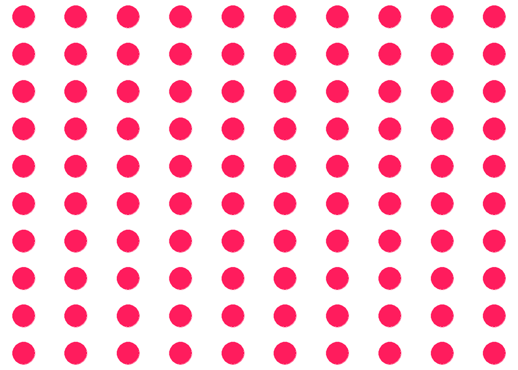

(a) IBR

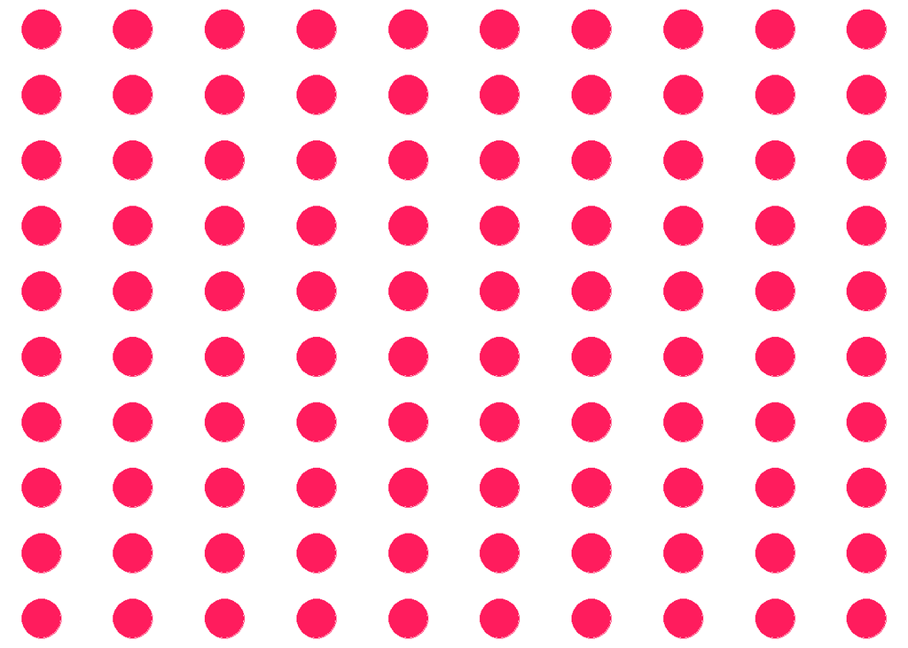

(b) BVD

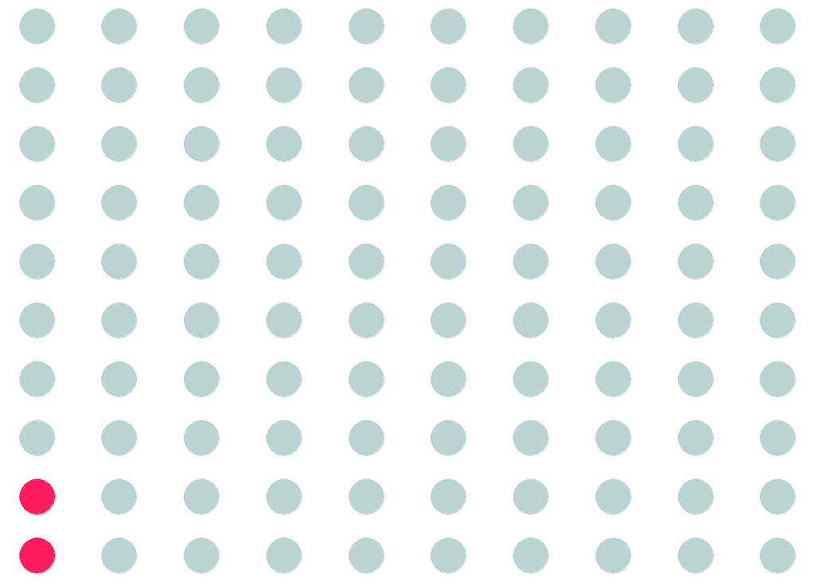

(c) TB

Figure 1.1: Risk of disease entry

The main pathways of disease entry are: **Animals from other origin** and **Animal transport**.

[figure not shown]

(a) IBR

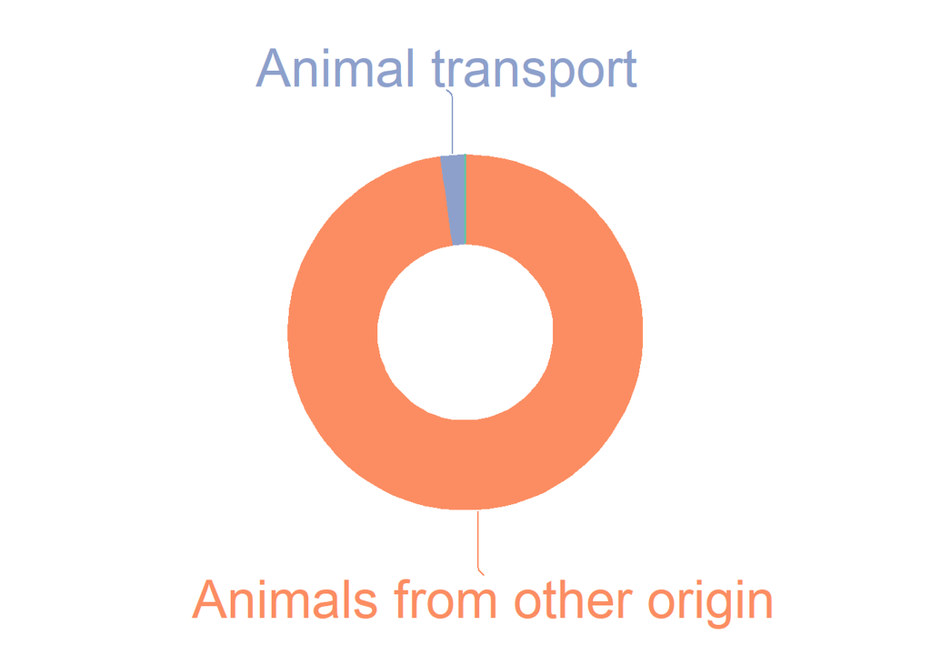

(b) BVD

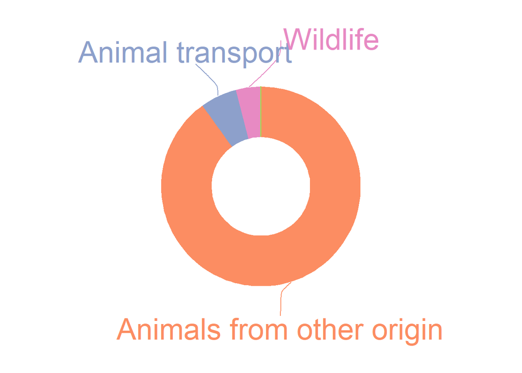

(c) TB

Figure 1.2: Risk of disease entry by pathway

## **Infectious Bovine Rhinotracheitis (IBR)**

### Current risk

Annual risk of IBR entry in the farm: **100%** (99.9-100%)

By pathway:

- Animals from other origin: **98.3%** (97.1-99%)
- Animal transport: **71%** (51.1-85.5%)
- Neigbouring farms: **0.00466%** (0.000211-0.02%)
- Vehicle visits to the farm: **0.000353%** (2.96e-05-0.0017%)

### Risk reduction of biosecurity measures

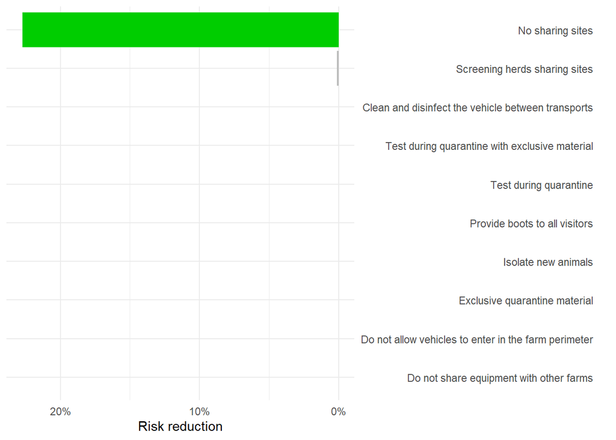

## **Bovine viral diarrhea (BVD)**

### Current risk

Annual risk of BVD entry in the farm: **100%** (100-100%)

By pathway:

- Animals from other origin: **100%** (99.9-100%)
- Animal transport: **2.27%** (0.481-7.72%)
- Vehicle visits to the farm: **0.000292%** (2.38e-05-0.00158%)
- Neigbouring farms: **5.29e-11%** (1.44e-13-8.46e-10%)

### Risk reduction of biosecurity measures

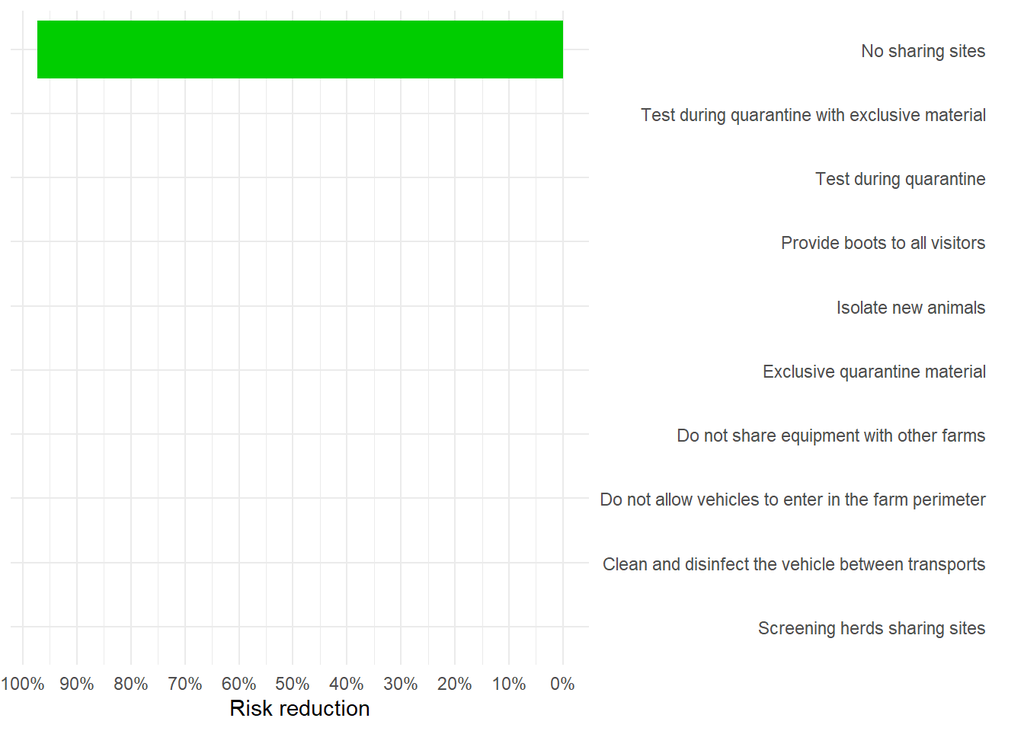

## **Bovine Tuberculosis (TB)**

### Current risk

Annual risk of TB entry in the farm: **1.05%** (0.783-1.42%)

By pathway:

- Animals from other origin: **0.992%** (0.724-1.34%)
- Animal transport: **0.0651%** (0.0284-0.118%)
- Wildlife: **0.0442%** (0.0132-0.119%)
- Neigbouring farms: **5.26e-07%** (6.6e-11-1.68e-05%)
- Vehicle visits to the farm: **1.83e-08%** (5.52e-11-5.82e-07%)

### Risk reduction of biosecurity measures

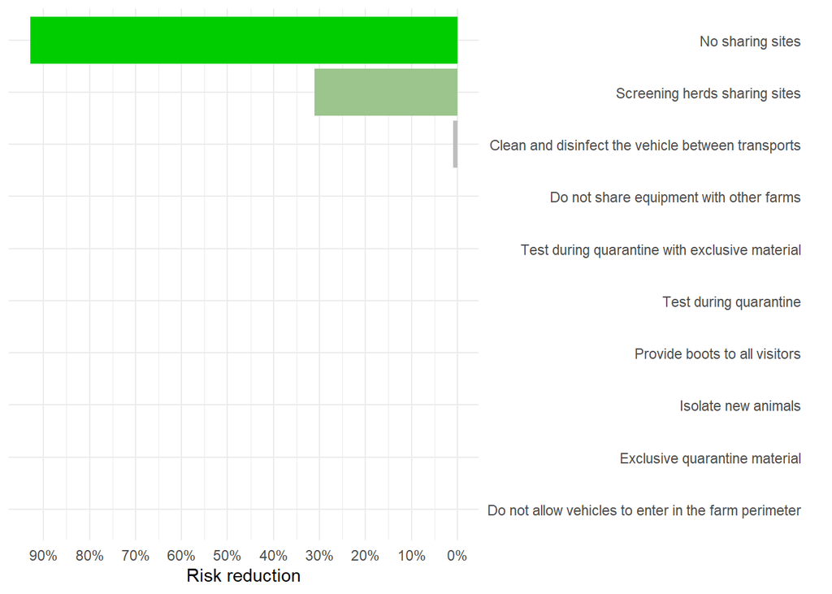

# 🐄 Description of the farm

## Farm information

**Location:** , Andorra

**Farm type:** Beef cattle, NA

**Cattle cens:**

- 30 Calves ( <8 m)
- 10 Heifers (8 - 24 m)
- 18 Adult cows (>24 m)
- 2 Bulls

**Other animals in the farm:**

- **Direct contact with cattle:** 10 sheep, 2 dogs, 2 cats
- **No direct contact with cattle:**

**Neighbours**: 1 cattle farms within a 1-2km radious, no direct contact (IBR: 0.00466%, BVD: 5.29e-11%, TB: 5.26e-07%)

## Farm vehicles

| veh_id | Size | Shared | Cleaning |
| --- | --- | --- | --- |
| Camió (a) | 20m2 | Shared with 5 cattle farms | From time to time |
| Remolc (c) | 5m2 | Shared with 5 cattle farms | From time to time |

## Visits

### People entering the barn

| Visit | Type | Frequency | Boots | Equipment | Risk |
| --- | --- | --- | --- | --- | --- |
| Veterinaris | External veterinarians | 10 | Always used in other farms, always cleaned and disinfected | Always used in other farms, always cleaned and disinfected | IBR: 0.0245%, BVD: 0.0266%, TB: 2.09e-05% |
| Altres ramaders | Other farmers | 12 | Always used in other farms, unk cleaned and disinfected | Never used in other farms | IBR: -0.0221%, BVD: -0.0166%, TB: -7.82e-06% |
| Podòleg | Other animal professionals (e.g. hoof trimmer) | 5 | Always used in other farms, unk cleaned and disinfected | Always used in other farms, always cleaned and disinfected | IBR: -0.169%, BVD: -0.127%, TB: -4.95e-05% |

### Vehicles entering the farm perimeter

| Visit | Type | Frequency | Driver | Risk |
| --- | --- | --- | --- | --- |
| Pinso | Feed vehicle | 12 | - | IBR: 0.000291%, BVD: 0.00024%, TB: 8.42e-09% |
| Cadàvers | Rendering vehicle | 1 | - | IBR: 3.96e-05%, BVD: 2.93e-05%, TB: 9.76e-10% |
| Camió per vida | Calf transport vehicle (own and not shared) | 5 | - | IBR: 0%, BVD: 0%, TB: 0% |

# 🚚 Movements

Animal movements in the last 12 months

| mov_id | When | Origin | Animals moved | Shared site | Vehicle used | Risk |
| --- | --- | --- | --- | --- | --- | --- |
| pastures_estiu | 🔁 Recurrent round: 1 times/year, out for 140 days | Pasture: Andorra | 20 Calves ( <8 m), 8 Heifers (8 - 24 m), 16 Adult cows (>24 m), 2 Bulls | Shared with 250 animals from 5 farms (presence of bulls) | Own Remolc | IBR: 100%, BVD: 100%, TB: 0.995% |
| pastures_tardor | 🔁 Recurrent round: 1 times/year, out for 15 days | Pasture: Andorra | 20 Calves ( <8 m), 8 Heifers (8 - 24 m), 16 Adult cows (>24 m), 2 Bulls | No | External | IBR: 70.5%, BVD: 2.25%, TB: 0.0616% |
| vaques | ➡️ One-off entry: 2023-05-15 | Other farm/s: Lleida | 2 Adult cows (>24 m) | - | Own Remolc | negligible risk |
| vedelles_i_toro | ➡️ One-off entry: 2023-10-01 | Other farm/s: Lleida | 4 Heifers (8 - 24 m), 1 Bulls | - | Own Remolc | negligible risk |

### Health status and tests in origin

[output not shown]

### Quarantine

#### Characteristics

*No quarantine*

# 🐗 Wildlife

**Wildlife:** IBR: -, BVD: -, TB: 0.0442%

### Farm water points

*No outdoors water points*

### Pasture water points

*No pasture water points*

# Comments

*No survey comments*

# Technical Annex